# Laboratorio 4.2: Clustering y Agrupamiento

Author

Minería de Datos - Grado en Matemáticas

# Introducción

En este laboratorio trabajaremos con **algoritmos de clustering**, tanto métodos de partición como métodos jerárquicos. Nos centraremos en:

- **Clustering no jerárquico**: k-medias y k-medoides
- **Clustering jerárquico**: Aglomerativo y Divisivo
- **Selección del número óptimo de clusters**
- **Evaluación de la calidad del clustering**
- **Mapas auto-organizados de Kohonen (SOM)**

## Objetivos del laboratorio

1. Implementar y comparar diferentes algoritmos de clustering
2. Aprender a seleccionar el número óptimo de clusters (k)
3. Interpretar dendrogramas y resultados de clustering jerárquico
4. Evaluar la calidad de los clusters obtenidos
5. Aplicar clustering a casos de uso reales

# Configuración inicial

```r
# Librerías necesarias
library(tidyverse)
library(cluster)
library(factoextra)
library(dendextend)
library(NbClust)
library(kohonen)
library(pheatmap)
library(gridExtra)
library(mclust)

# Configuración de gráficos
theme_set(theme_minimal())
set.seed(123)
```

# Parte 1: Clustering No Jerárquico

## 1.1 K-Medias: Fundamentos

### Ejercicio 1.1: K-medias paso a paso

**Objetivo**: Implementar k-medias manualmente para entender el algoritmo.

```r
cat("=== ALGORITMO K-MEDIAS PASO A PASO ===\n\n")
```

```
=== ALGORITMO K-MEDIAS PASO A PASO ===
```

```r
# Crear datos simples en 2D
set.seed(42)
datos <- data.frame(
  x = c(1, 1.5, 2, 8, 8.5, 9, 1.2, 1.8, 8.2, 9.5),
  y = c(1, 1.2, 1.5, 8, 8.2, 9, 1.3, 2, 8.5, 9.2)
)

cat("PASO 0: Datos originales\n")
```

```
PASO 0: Datos originales
```

```r
print(datos)
```

```
     x   y
1  1.0 1.0
2  1.5 1.2
3  2.0 1.5
4  8.0 8.0
5  8.5 8.2
6  9.0 9.0
7  1.2 1.3
8  1.8 2.0
9  8.2 8.5
10 9.5 9.2
```

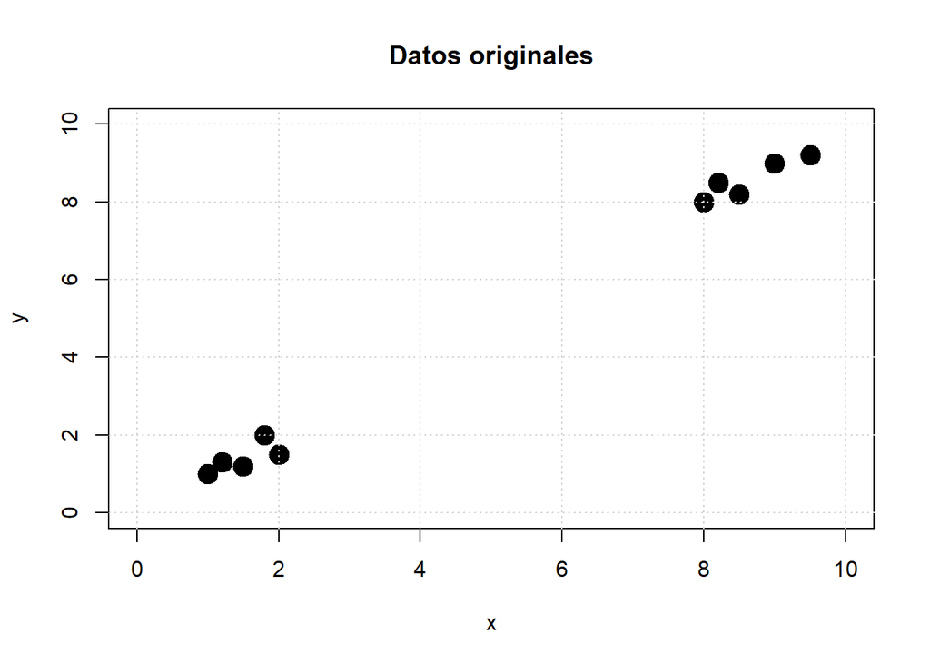

```r
# Visualizar datos originales
plot(datos$x, datos$y, pch = 19, cex = 2,
     main = "Datos originales",
     xlab = "x", ylab = "y", xlim = c(0, 10), ylim = c(0, 10))
grid()
```

```r
# Parámetros
K <- 2
max_iter <- 10

# PASO 1: Inicialización - seleccionar K centroides aleatorios
cat("\n\nPASO 1: Inicialización\n")
```

```
PASO 1: Inicialización
```

```r
cat("Seleccionar K =", K, "centroides iniciales aleatorios\n\n")
```

```
Seleccionar K = 2 centroides iniciales aleatorios
```

```r
indices_iniciales <- sample(1:nrow(datos), K)
centroides <- datos[indices_iniciales, ]
rownames(centroides) <- paste0("C", 1:K)
cat("Centroides iniciales:\n")
```

```
Centroides iniciales:
```

```r
print(centroides)
```

```
     x   y
C1 1.0 1.0
C2 8.5 8.2
```

```
--- ITERACIÓN 1 ---
Asignaciones: 1 1 1 2 2 2 1 1 2 2
```

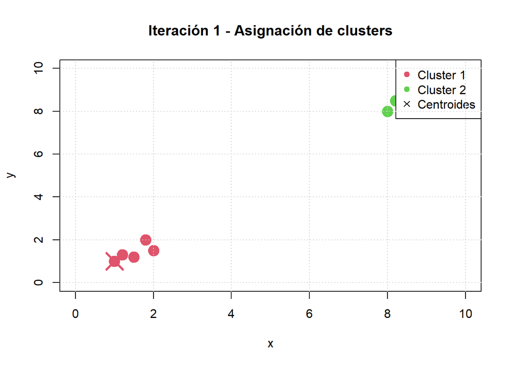

```
Nuevos centroides:
     x    y
1 1.50 1.40
2 8.64 8.58

--- ITERACIÓN 2 ---
Asignaciones: 1 1 1 2 2 2 1 1 2 2
```

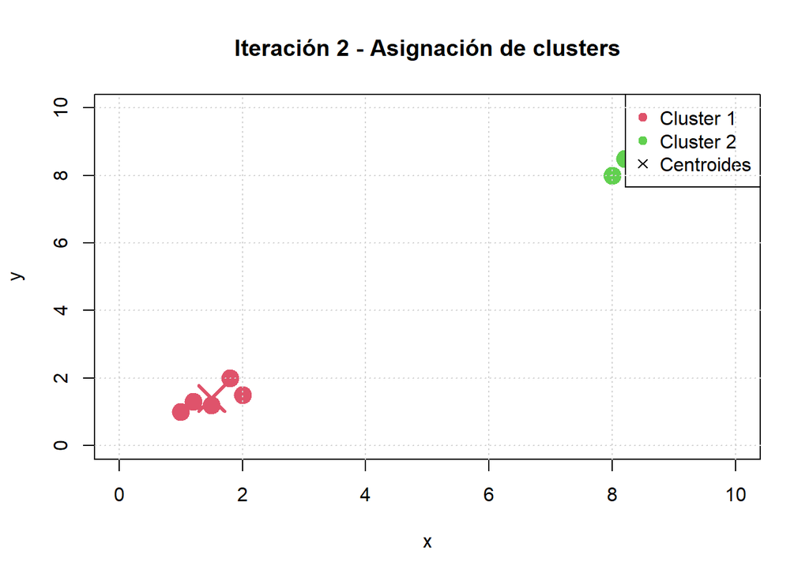

```
Nuevos centroides:
     x    y
1 1.50 1.40
2 8.64 8.58

¡Convergencia alcanzada!
```

```r
# Función para asignar cada punto al centroide más cercano
asignar_clusters <- function(datos, centroides) {
  distancias <- matrix(0, nrow = nrow(datos), ncol = nrow(centroides))
  for(i in 1:nrow(centroides)) {
    distancias[, i] <- sqrt((datos$x - centroides$x[i])^2 +
                            (datos$y - centroides$y[i])^2)
  }
  apply(distancias, 1, which.min)
}

# Función para actualizar centroides
actualizar_centroides <- function(datos, clusters) {
  K <- max(clusters)
  nuevos_centroides <- data.frame(x = numeric(K), y = numeric(K))
  for(k in 1:K) {
    puntos_cluster <- datos[clusters == k, ]
    nuevos_centroides[k, ] <- colMeans(puntos_cluster)
  }
  nuevos_centroides
}

# Iteraciones
convergencia <- FALSE
iter <- 1

while(!convergencia && iter <= max_iter) {
  cat("\n--- ITERACIÓN", iter, "---\n")

  # PASO 2: Asignar cada punto al centroide más cercano
  clusters <- asignar_clusters(datos, centroides)
  cat("Asignaciones:", clusters, "\n")

  # Visualizar
  par(mfrow = c(1, 1))
  plot(datos$x, datos$y, col = clusters + 1, pch = 19, cex = 2,
       main = paste("Iteración", iter, "- Asignación de clusters"),
       xlab = "x", ylab = "y", xlim = c(0, 10), ylim = c(0, 10))
  points(centroides$x, centroides$y, col = 2:(K+1), pch = 4, cex = 3, lwd = 3)
  legend("topright", legend = c("Cluster 1", "Cluster 2", "Centroides"),
         col = c(2, 3, 1), pch = c(19, 19, 4))
  grid()

  # PASO 3: Actualizar centroides
  nuevos_centroides <- actualizar_centroides(datos, clusters)
  cat("Nuevos centroides:\n")
  print(nuevos_centroides)

  # PASO 4: Verificar convergencia
  if(all(abs(centroides - nuevos_centroides) < 1e-6)) {
    cat("\n¡Convergencia alcanzada!\n")
    convergencia <- TRUE
  } else {
    centroides <- nuevos_centroides
    iter <- iter + 1
  }
}
```

```r
cat("\n\n=== RESULTADO FINAL ===\n")
```

```
=== RESULTADO FINAL ===
```

```r
cat("Número de iteraciones:", iter, "\n")
```

```
Número de iteraciones: 2
```

```r
cat("Centroides finales:\n")
```

```
Centroides finales:
```

```r
print(centroides)
```

```
     x    y
1 1.50 1.40
2 8.64 8.58
```

```r
cat("\nAsignación final de clusters:\n")
```

```
Asignación final de clusters:
```

```r
datos_resultado <- cbind(datos, cluster = clusters)
print(datos_resultado)
```

```
     x   y cluster
1  1.0 1.0       1
2  1.5 1.2       1
3  2.0 1.5       1
4  8.0 8.0       2
5  8.5 8.2       2
6  9.0 9.0       2
7  1.2 1.3       1
8  1.8 2.0       1
9  8.2 8.5       2
10 9.5 9.2       2
```

```r
# Calcular varianza intracluster (Within-cluster sum of squares)
wcss <- sum(sapply(1:K, function(k) {
  puntos <- datos[clusters == k, ]
  sum((puntos$x - centroides$x[k])^2 + (puntos$y - centroides$y[k])^2)
}))
cat("\nVarianza intracluster (WCSS):", round(wcss, 4), "\n")
```

```
Varianza intracluster (WCSS): 3.8
```

**Pregunta 1**: ¿Por qué es importante el paso de inicialización en k-medias?

### Ejercicio 1.2: K-medias con kmeans()

```r
# Usar dataset iris
data(iris)
X <- iris[, 1:4]
X_scaled <- scale(X)

# Aplicar k-medias con K=3
set.seed(123)
kmeans_result <- kmeans(X_scaled, centers = 3, nstart = 25)

cat("=== RESULTADOS DE K-MEDIAS (K=3) ===\n\n")
```

```
=== RESULTADOS DE K-MEDIAS (K=3) ===
```

```r
cat("Tamaño de cada cluster:\n")
```

```
Tamaño de cada cluster:
```

```r
print(kmeans_result$size)
```

```
[1] 50 53 47
```

```r
cat("\nCentroides de los clusters (en escala estandarizada):\n")
```

```
Centroides de los clusters (en escala estandarizada):
```

```r
print(round(kmeans_result$centers, 3))
```

```
  Sepal.Length Sepal.Width Petal.Length Petal.Width
1       -1.011       0.850       -1.301      -1.251
2       -0.050      -0.880        0.347       0.281
3        1.132       0.088        0.993       1.014
```

```r
cat("\nVarianza intracluster (within-cluster SS):\n")
```

```
Varianza intracluster (within-cluster SS):
```

```r
print(kmeans_result$withinss)
```

```
[1] 47.35062 44.08754 47.45019
```

```r
cat("Total within-cluster SS:", kmeans_result$tot.withinss, "\n")
```

```
Total within-cluster SS: 138.8884
```

```r
cat("Between-cluster SS:", kmeans_result$betweenss, "\n")
```

```
Between-cluster SS: 457.1116
```

```r
# Proporción de varianza explicada
prop_var_explicada <- kmeans_result$betweenss / kmeans_result$totss * 100
cat(sprintf("\nProporción de varianza explicada: %.2f%%\n", prop_var_explicada))
```

```
Proporción de varianza explicada: 76.70%
```

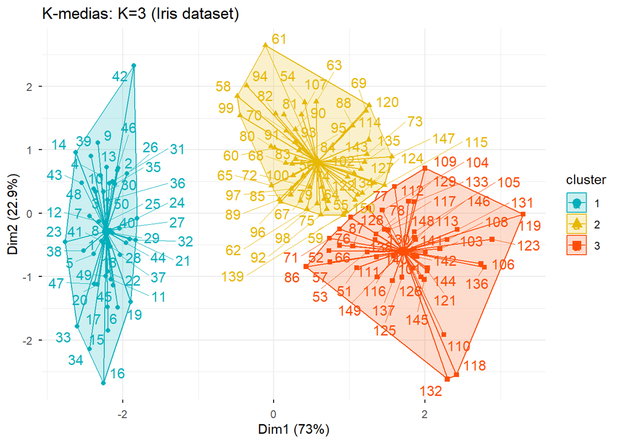

```r
# Visualizar clusters
fviz_cluster(kmeans_result, data = X_scaled,
             palette = c("#00AFBB", "#E7B800", "#FC4E07"),
             ellipse.type = "convex",
             star.plot = TRUE,
             repel = TRUE,
             ggtheme = theme_minimal(),
             main = "K-medias: K=3 (Iris dataset)")
```

```r
# Comparar con etiquetas reales
tabla_comparacion <- table(Cluster = kmeans_result$cluster, Especie = iris$Species)
cat("\n=== COMPARACIÓN CON ESPECIES REALES ===\n")
```

```
=== COMPARACIÓN CON ESPECIES REALES ===
```

```r
print(tabla_comparacion)
```

```
       Especie
Cluster setosa versicolor virginica
      1     50          0         0
      2      0         39        14
      3      0         11        36
```

```r
cat("\nInterpretación:\n")
```

```
Interpretación:
```

```r
cat("- Cluster 1 corresponde principalmente a:", names(which.max(tabla_comparacion[1, ])), "\n")
```

```
- Cluster 1 corresponde principalmente a: setosa
```

```r
cat("- Cluster 2 corresponde principalmente a:", names(which.max(tabla_comparacion[2, ])), "\n")
```

```
- Cluster 2 corresponde principalmente a: versicolor
```

```r
cat("- Cluster 3 corresponde principalmente a:", names(which.max(tabla_comparacion[3, ])), "\n")
```

```
- Cluster 3 corresponde principalmente a: virginica
```

### Ejercicio 1.3: Efecto de la inicialización

```r
cat("=== SENSIBILIDAD A LA INICIALIZACIÓN ===\n\n")
```

```
=== SENSIBILIDAD A LA INICIALIZACIÓN ===
```

```r
# Ejecutar k-medias 10 veces con diferentes inicializaciones
resultados <- list()
wcss_values <- numeric(10)

for(i in 1:10) {
  set.seed(i)
  km <- kmeans(X_scaled, centers = 3, nstart = 1)
  resultados[[i]] <- km
  wcss_values[i] <- km$tot.withinss
}

cat("WCSS para 10 inicializaciones diferentes:\n")
```

```
WCSS para 10 inicializaciones diferentes:
```

```r
wcss_df <- data.frame(
  Inicialización = 1:10,
  WCSS = round(wcss_values, 4),
  Es_óptimo = ifelse(wcss_values == min(wcss_values), "SÍ", "")
)
print(wcss_df)
```

```
   Inicialización     WCSS Es_óptimo
1               1 138.8884        SÍ
2               2 138.8884        SÍ
3               3 189.7512
4               4 138.8884        SÍ
5               5 138.8884        SÍ
6               6 138.8884        SÍ
7               7 138.8884        SÍ
8               8 138.8884        SÍ
9               9 138.8884        SÍ
10             10 138.8884        SÍ
```

```r
cat(sprintf("\nWCSS mínimo: %.4f\n", min(wcss_values)))
```

```
WCSS mínimo: 138.8884
```

```r
cat(sprintf("WCSS máximo: %.4f\n", max(wcss_values)))
```

```
WCSS máximo: 189.7512
```

```r
cat(sprintf("Diferencia: %.4f (%.2f%%)\n",
            max(wcss_values) - min(wcss_values),
            (max(wcss_values) - min(wcss_values)) / min(wcss_values) * 100))
```

```
Diferencia: 50.8629 (36.62%)
```

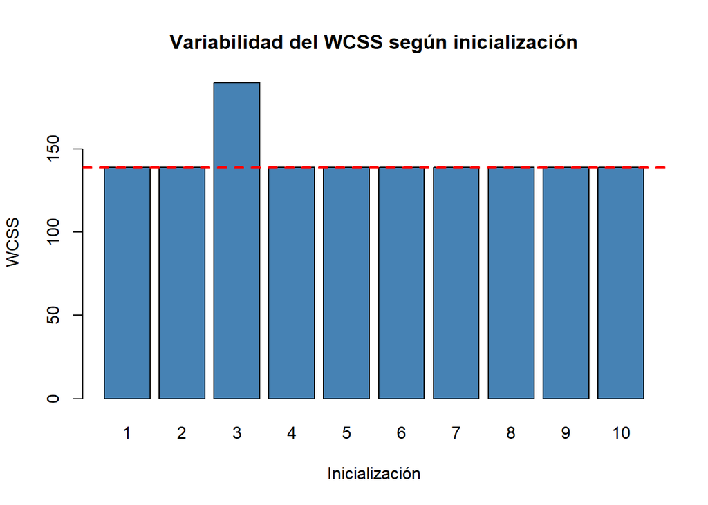

```r
# Visualizar variabilidad
barplot(wcss_values, names.arg = 1:10, col = "steelblue",
        main = "Variabilidad del WCSS según inicialización",
        xlab = "Inicialización", ylab = "WCSS")
abline(h = min(wcss_values), col = "red", lty = 2, lwd = 2)
```

```r
cat("\n=== SOLUCIÓN: Usar nstart ===\n")
```

```
=== SOLUCIÓN: Usar nstart ===
```

```r
cat("El parámetro 'nstart' ejecuta el algoritmo múltiples veces\n")
```

```
El parámetro 'nstart' ejecuta el algoritmo múltiples veces
```

```r
cat("y devuelve la mejor solución (menor WCSS)\n\n")
```

```
y devuelve la mejor solución (menor WCSS)
```

```r
# Comparar nstart=1 vs nstart=25
set.seed(123)
km_nstart1 <- kmeans(X_scaled, centers = 3, nstart = 1)
km_nstart25 <- kmeans(X_scaled, centers = 3, nstart = 25)

cat("WCSS con nstart=1:", km_nstart1$tot.withinss, "\n")
```

```
WCSS con nstart=1: 138.8884
```

```r
cat("WCSS con nstart=25:", km_nstart25$tot.withinss, "\n")
```

```
WCSS con nstart=25: 138.8884
```

```r
cat("\n¡Siempre usa nstart >= 20-25 para evitar mínimos locales!\n")
```

```
¡Siempre usa nstart >= 20-25 para evitar mínimos locales!
```

**Pregunta 2**: ¿Qué valor recomendarías para el parámetro nstart?

## 1.2 K-Medoides (PAM)

### Ejercicio 1.4: K-medoides con PAM

**Objetivo**: Comparar k-medias con k-medoides (más robusto a outliers).

```r
cat("=== K-MEDOIDES (PAM - Partitioning Around Medoids) ===\n\n")
```

```
=== K-MEDOIDES (PAM - Partitioning Around Medoids) ===
```

```r
# Aplicar PAM
pam_result <- pam(X_scaled, k = 3)

cat("Tamaño de cada cluster:\n")
```

```
Tamaño de cada cluster:
```

```r
print(pam_result$clusinfo)
```

```
     size max_diss   av_diss diameter separation
[1,]   50 2.600722 0.8137338 5.034198  1.5533592
[2,]   45 2.326061 0.9215472 3.537354  0.2875493
[3,]   55 2.135226 0.8945355 3.565921  0.2875493
```

```r
cat("\n\nMedoides (índices de observaciones):\n")
```

```
Medoides (índices de observaciones):
```

```r
print(pam_result$medoids)
```

```
     Sepal.Length Sepal.Width Petal.Length Petal.Width
[1,]   -1.0184372   0.7861738   -1.2791040  -1.3110521
[2,]    1.1553023  -0.1315388    0.9868021   1.1816087
[3,]   -0.1730941  -0.5903951    0.4203256   0.1320673
```

```r
cat("\nMedoides corresponden a especies:\n")
```

```
Medoides corresponden a especies:
```

```r
for(i in 1:3) {
  idx <- pam_result$id.med[i]
  cat(sprintf("Cluster %d: Observación %d (%s)\n",
              i, idx, iris$Species[idx]))
}
```

```
Cluster 1: Observación 8 (setosa)
Cluster 2: Observación 113 (virginica)
Cluster 3: Observación 56 (versicolor)
```

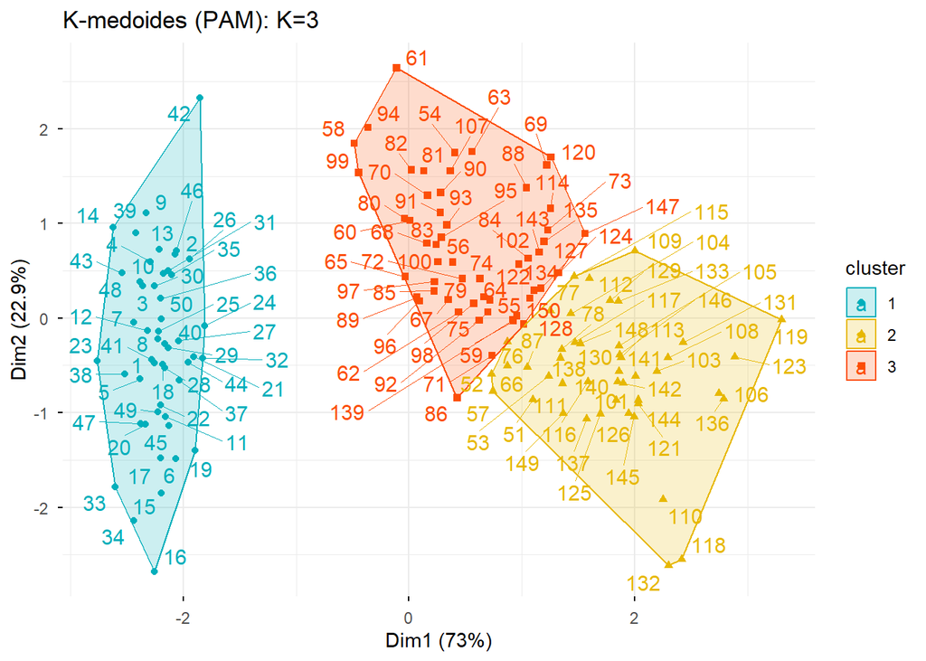

```r
# Visualizar
fviz_cluster(pam_result, data = X_scaled,
             palette = c("#00AFBB", "#E7B800", "#FC4E07"),
             ellipse.type = "convex",
             repel = TRUE,
             ggtheme = theme_minimal(),
             main = "K-medoides (PAM): K=3")
```

```
  cluster size ave.sil.width
1       1   50          0.63
2       2   45          0.35
3       3   55          0.38
```

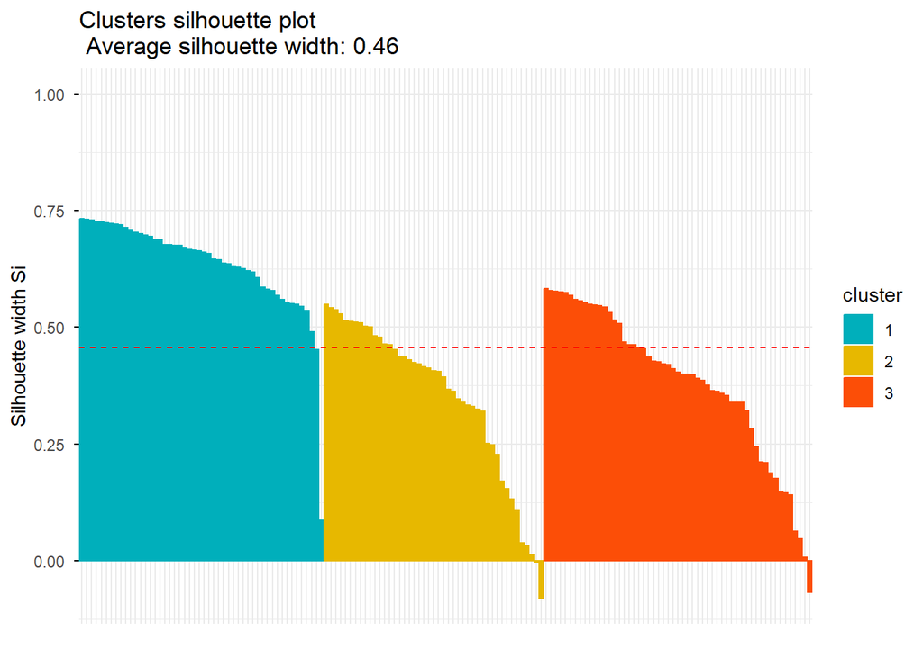

```r
# Silhouette plot
fviz_silhouette(pam_result, palette = c("#00AFBB", "#E7B800", "#FC4E07"),
                ggtheme = theme_minimal())
```

```r
cat("\n\nSilhouette promedio:", round(pam_result$silinfo$avg.width, 4), "\n")
```

```
Silhouette promedio: 0.4566
```

```r
cat("\nInterpretación del coeficiente Silhouette:\n")
```

```
Interpretación del coeficiente Silhouette:
```

```r
cat("- Valores cercanos a 1: excelente asignación\n")
```

```
- Valores cercanos a 1: excelente asignación
```

```r
cat("- Valores cercanos a 0: entre dos clusters\n")
```

```
- Valores cercanos a 0: entre dos clusters
```

```r
cat("- Valores negativos: probablemente en el cluster incorrecto\n")
```

```
- Valores negativos: probablemente en el cluster incorrecto
```

### Ejercicio 1.5: Robustez a outliers - K-medias vs K-medoides

```r
cat("=== ROBUSTEZ A OUTLIERS ===\n\n")
```

```
=== ROBUSTEZ A OUTLIERS ===
```

```r
# Crear datos con outliers
set.seed(123)
datos_normales <- rbind(
  matrix(rnorm(100, mean = 0, sd = 1), ncol = 2),
  matrix(rnorm(100, mean = 5, sd = 1), ncol = 2)
)

# Agregar 5 outliers extremos
outliers <- matrix(c(10, 10, 10, -5, -5, 10, -5, -5, 12, 0), ncol = 2)
datos_con_outliers <- rbind(datos_normales, outliers)
datos_con_outliers <- as.data.frame(datos_con_outliers)
colnames(datos_con_outliers) <- c("x", "y")

cat("Total observaciones:", nrow(datos_con_outliers), "\n")
```

```
Total observaciones: 105
```

```r
cat("Outliers:", nrow(outliers), "\n\n")
```

```
Outliers: 5
```

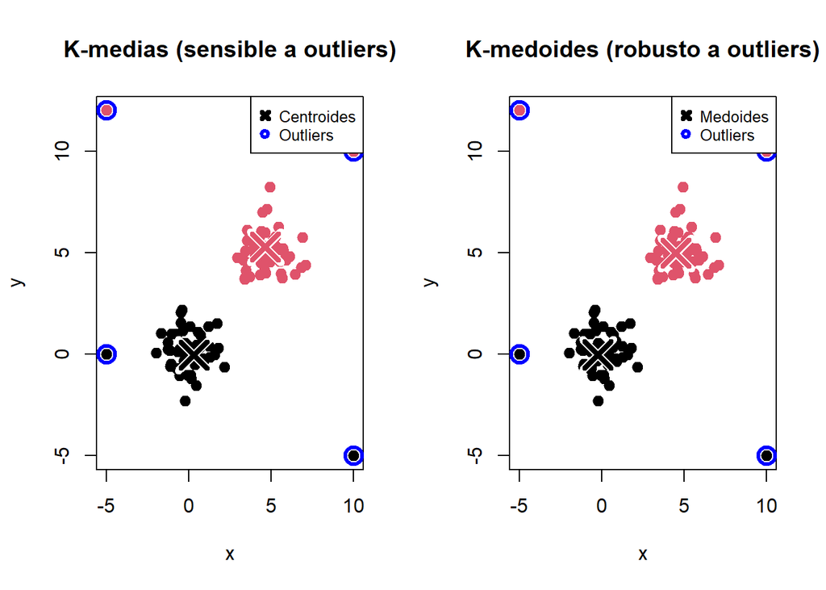

```r
# K-medias
km <- kmeans(datos_con_outliers, centers = 2, nstart = 25)

# K-medoides
pam_res <- pam(datos_con_outliers, k = 2)

# Visualizar comparación
par(mfrow = c(1, 2))

# K-medias
plot(datos_con_outliers$x, datos_con_outliers$y,
     col = km$cluster, pch = 19, cex = 1.2,
     main = "K-medias (sensible a outliers)",
     xlab = "x", ylab = "y")
# Dibujar centroides: primero borde blanco grueso, luego símbolo de color
for(i in 1:nrow(km$centers)) {
  points(km$centers[i, 1], km$centers[i, 2],
         col = "white", pch = 4, cex = 3.5, lwd = 6)  # Borde blanco
  points(km$centers[i, 1], km$centers[i, 2],
         col = i, pch = 4, cex = 3, lwd = 4)  # X del color del cluster
}
# Resaltar outliers con círculos azules
points(outliers[, 1], outliers[, 2], col = "blue", pch = 1, cex = 2, lwd = 3)
legend("topright", c("Centroides", "Outliers"),
       col = c("black", "blue"), pch = c(4, 1), pt.lwd = c(4, 3), cex = 0.8)

# K-medoides
plot(datos_con_outliers$x, datos_con_outliers$y,
     col = pam_res$cluster, pch = 19, cex = 1.2,
     main = "K-medoides (robusto a outliers)",
     xlab = "x", ylab = "y")
# Dibujar medoides: primero borde blanco grueso, luego símbolo de color
# pam_res$id.med contiene los índices de las observaciones que son medoides
medoid_coords <- datos_con_outliers[pam_res$id.med, ]
for(i in 1:nrow(medoid_coords)) {
  points(medoid_coords$x[i], medoid_coords$y[i],
         col = "white", pch = 4, cex = 3.5, lwd = 6)  # Borde blanco
  points(medoid_coords$x[i], medoid_coords$y[i],
         col = i, pch = 4, cex = 3, lwd = 4)  # X del color del cluster
}
# Resaltar outliers con círculos azules
points(outliers[, 1], outliers[, 2], col = "blue", pch = 1, cex = 2, lwd = 3)
legend("topright", c("Medoides", "Outliers"),
       col = c("black", "blue"), pch = c(4, 1), pt.lwd = c(4, 3), cex = 0.8)
```

```r
par(mfrow = c(1, 1))

cat("=== COMPARACIÓN DE RESULTADOS ===\n")
```

```
=== COMPARACIÓN DE RESULTADOS ===
```

```r
cat("K-medias - WCSS:", km$tot.withinss, "\n")
```

```
K-medias - WCSS: 635.8664
```

```r
cat("K-medoides - Dissimilarity:", pam_res$objective, "\n\n")
```

```
K-medoides - Dissimilarity: 2.020884 1.579132
```

```r
cat("Observación: Los medoides (puntos reales del dataset) son más\n")
```

```
Observación: Los medoides (puntos reales del dataset) son más
```

```r
cat("robustos que las medias cuando hay outliers presentes.\n")
```

```
robustos que las medias cuando hay outliers presentes.
```

**Pregunta 3**: ¿En qué situaciones preferirías usar k-medoides en lugar de k-medias?

## 1.3 Selección del Número Óptimo de Clusters

### Ejercicio 1.6: Método del Codo (Elbow)

```r
cat("=== MÉTODO DEL CODO (ELBOW METHOD) ===\n\n")
```

```
=== MÉTODO DEL CODO (ELBOW METHOD) ===
```

```r
# Calcular WCSS para diferentes valores de K
k_values <- 1:10
wcss_values <- numeric(length(k_values))

for(k in k_values) {
  km <- kmeans(X_scaled, centers = k, nstart = 25)
  wcss_values[k] <- km$tot.withinss
}

# Visualizar
elbow_df <- data.frame(K = k_values, WCSS = wcss_values)
print(elbow_df)
```

```
    K      WCSS
1   1 596.00000
2   2 220.87929
3   3 138.88836
4   4 113.33162
5   5  90.20190
6   6  79.46523
7   7  70.18758
8   8  62.02699
9   9  54.68037
10 10  46.84282
```

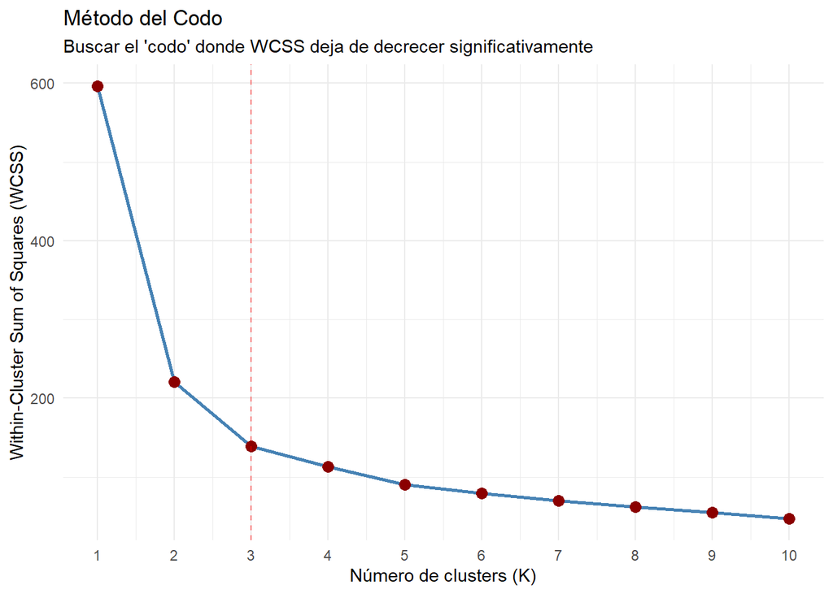

```r
# Gráfico del codo
ggplot(elbow_df, aes(x = K, y = WCSS)) +
  geom_line(color = "steelblue", size = 1) +
  geom_point(color = "darkred", size = 3) +
  geom_vline(xintercept = 3, linetype = "dashed", color = "red", alpha = 0.5) +
  labs(title = "Método del Codo",
       subtitle = "Buscar el 'codo' donde WCSS deja de decrecer significativamente",
       x = "Número de clusters (K)",
       y = "Within-Cluster Sum of Squares (WCSS)") +
  theme_minimal() +
  scale_x_continuous(breaks = 1:10)
```

```r
cat("\nInterpretación:\n")
```

```
Interpretación:
```

```r
cat("- El WCSS siempre decrece al aumentar K\n")
```

```
- El WCSS siempre decrece al aumentar K
```

```r
cat("- Buscar el punto donde el decremento se vuelve marginal\n")
```

```
- Buscar el punto donde el decremento se vuelve marginal
```

```r
cat("- En este caso, el 'codo' sugiere K = 2 o K = 3\n")
```

```
- En este caso, el 'codo' sugiere K = 2 o K = 3
```

```r
# Calcular diferencias (segunda derivada aproximada)
diferencias <- -diff(wcss_values)
dif2 <- -diff(diferencias)

cat("\n=== ANÁLISIS DE CURVATURA ===\n")
```

```
=== ANÁLISIS DE CURVATURA ===
```

```r
cat("Reducción de WCSS al aumentar K:\n")
```

```
Reducción de WCSS al aumentar K:
```

```r
for(i in 2:length(wcss_values)) {
  cat(sprintf("K=%d → K=%d: reducción = %.2f\n",
              i-1, i, diferencias[i-1]))
}
```

```
K=1 → K=2: reducción = 375.12
K=2 → K=3: reducción = 81.99
K=3 → K=4: reducción = 25.56
K=4 → K=5: reducción = 23.13
K=5 → K=6: reducción = 10.74
K=6 → K=7: reducción = 9.28
K=7 → K=8: reducción = 8.16
K=8 → K=9: reducción = 7.35
K=9 → K=10: reducción = 7.84
```

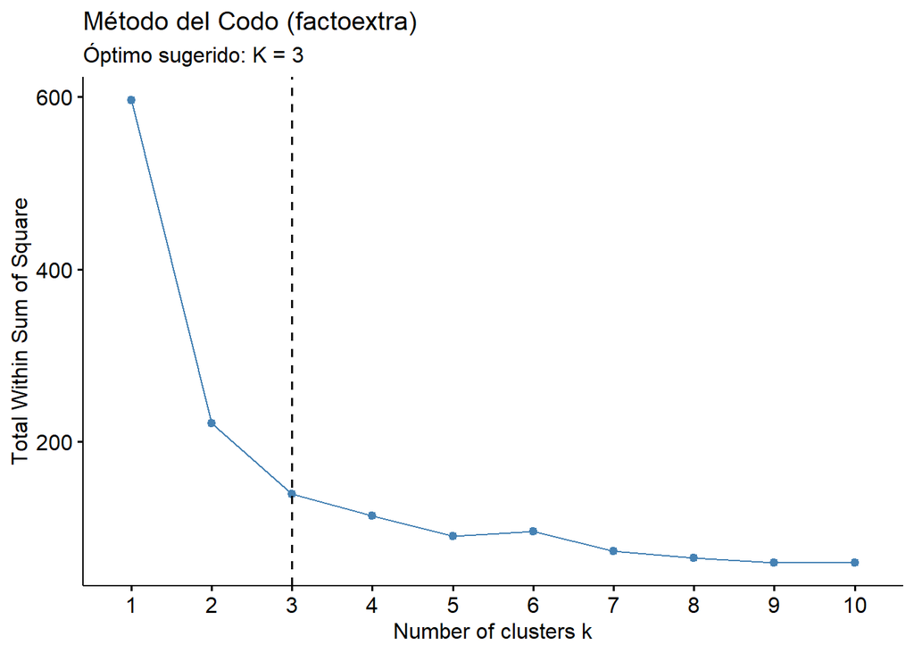

```r
# Método alternativo: usar factoextra
fviz_nbclust(X_scaled, kmeans, method = "wss", k.max = 10) +
  geom_vline(xintercept = 3, linetype = 2) +
  labs(title = "Método del Codo (factoextra)",
       subtitle = "Óptimo sugerido: K = 3")
```

**Pregunta 4**: ¿Qué limitaciones tiene el método del codo?

### Ejercicio 1.7: Método de la Silueta (Silhouette)

```r
cat("=== MÉTODO DE LA SILUETA ===\n\n")
```

```
=== MÉTODO DE LA SILUETA ===
```

```r
# Calcular silhouette promedio para diferentes valores de K
k_values <- 2:10
silhouette_avg <- numeric(length(k_values))

for(i in seq_along(k_values)) {
  k <- k_values[i]
  km <- kmeans(X_scaled, centers = k, nstart = 25)
  sil <- silhouette(km$cluster, dist(X_scaled))
  silhouette_avg[i] <- mean(sil[, 3])
}

# Visualizar
sil_df <- data.frame(K = k_values, Silhouette = silhouette_avg)
print(sil_df)
```

```
   K Silhouette
1  2  0.5817500
2  3  0.4599482
3  4  0.3838509
4  5  0.3419470
5  6  0.3229212
6  7  0.3254461
7  8  0.3326148
8  9  0.3297370
9 10  0.3523740
```

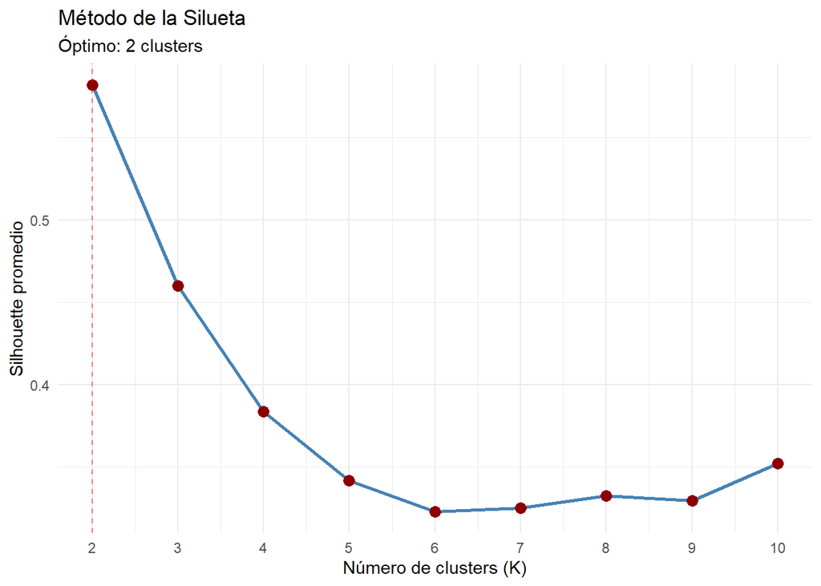

```r
ggplot(sil_df, aes(x = K, y = Silhouette)) +
  geom_line(color = "steelblue", size = 1) +
  geom_point(color = "darkred", size = 3) +
  geom_vline(xintercept = k_values[which.max(silhouette_avg)],
             linetype = "dashed", color = "red", alpha = 0.5) +
  labs(title = "Método de la Silueta",
       subtitle = paste("Óptimo:", k_values[which.max(silhouette_avg)], "clusters"),
       x = "Número de clusters (K)",
       y = "Silhouette promedio") +
  theme_minimal() +
  scale_x_continuous(breaks = 2:10)
```

```r
cat("\nÓptimo según Silhouette: K =", k_values[which.max(silhouette_avg)], "\n")
```

```
Óptimo según Silhouette: K = 2
```

```r
cat("Silhouette máximo:", round(max(silhouette_avg), 4), "\n")
```

```
Silhouette máximo: 0.5818
```

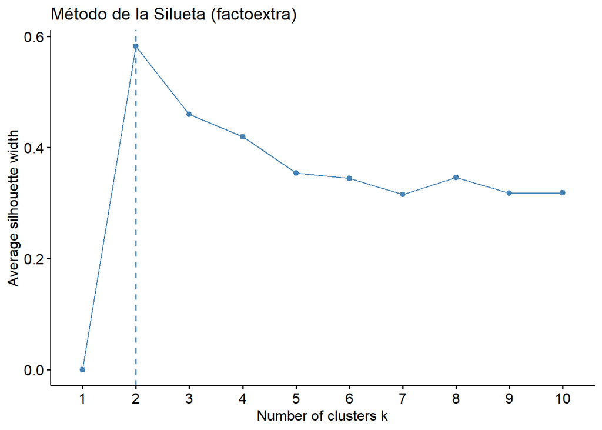

```r
# Método alternativo: usar factoextra
fviz_nbclust(X_scaled, kmeans, method = "silhouette", k.max = 10) +
  labs(title = "Método de la Silueta (factoextra)")
```

```r
# Análisis detallado para K óptimo
k_opt <- k_values[which.max(silhouette_avg)]
km_opt <- kmeans(X_scaled, centers = k_opt, nstart = 25)
sil_opt <- silhouette(km_opt$cluster, dist(X_scaled))

cat("\n=== ANÁLISIS DETALLADO PARA K =", k_opt, "===\n")
```

```
=== ANÁLISIS DETALLADO PARA K = 2 ===
```

```r
cat("Silhouette por cluster:\n")
```

```
Silhouette por cluster:
```

```r
print(summary(sil_opt))
```

```
Silhouette of 150 units in 2 clusters from silhouette.default(x = km_opt$cluster, dist = dist(X_scaled)) :
 Cluster sizes and average silhouette widths:
       50       100
0.6807337 0.5322582
Individual silhouette widths:
   Min. 1st Qu.  Median    Mean 3rd Qu.    Max.
 0.1256  0.5256  0.6065  0.5817  0.6636  0.7648
```

```
  cluster size ave.sil.width
1       1   50          0.68
2       2  100          0.53
```

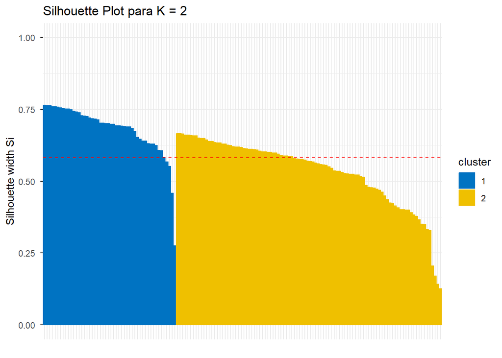

```r
# Visualizar silhouette plot
fviz_silhouette(sil_opt, palette = "jco", ggtheme = theme_minimal()) +
  labs(title = paste("Silhouette Plot para K =", k_opt))
```